# Exploration Livre de Poche

Jérôme THIBAULT

25/04/2018

# Introduction

Ce notebook explore l’ensemble des résumés de livres scrapés depuis le site du Livre de Poche, toutes collections confondues. Il se décompose de la manière suivante : - import et description succincte du jeu de données - nettoyage du texte - analyse descriptive - classification non supervisée

Ces différentes étapes doivent permettre de mieux appréhender le jeu de données, avant de s’engager dans une classification supervisée.

# Déroulement de la procédure

## Chargement des packages

On commence par charger les packages nécessaires : - tm, stringi, stringr, SnowballC : nettoyage de texte (normalisation, regexp, unicode, stemming) - tidyverse (dont dplyr et ggplot2) : librairies-outils plus modernes, proposées par Hadley Wickham (notamment grammaire proche du SQL) - wordcloud, RColorBrewer : générateur de nuages de mots, palettes de couleurs

```r
# install.packages("tm")
# install.packages("SnowballC")
# install.packages("wordcloud")
# install.packages("RColorBrewer")
library(tidyverse)
library(tm)
library(stringi)
library(stringr)
library(SnowballC)
library(wordcloud)
library(wordcloud2)
library(RColorBrewer)
```

## Import des données

On importe ensuite les données via readr (tidyverse). On en profite pour supprimer les colonnes inutiles :

```r
dfBookSummaries <- read_csv("dfAllBooksSummaries2405.csv", col_types = cols(X1 = col_skip(), X2 = col_skip(), text = col_character(), collection = col_factor(levels = c("Classiques", "Documents", "Imaginaire", "Littérature", "Policier", "Thriller"))))
```

## Description succincte des données

On résume le jeu de données importé : combien de collections et de résumés contient-il ?

```r
summary(dfBookSummaries)
```

```
##      text                 collection
##  Length:5096        Classiques : 364
##  Class :character   Documents  : 601
##  Mode  :character   Imaginaire : 498
##                     Littérature:2185
##                     Policier   : 703
##                     Thriller   : 745
```

On dénombre 5096 résumés, répartis dans 6 collections. La collection littérature est sur-exprimée :

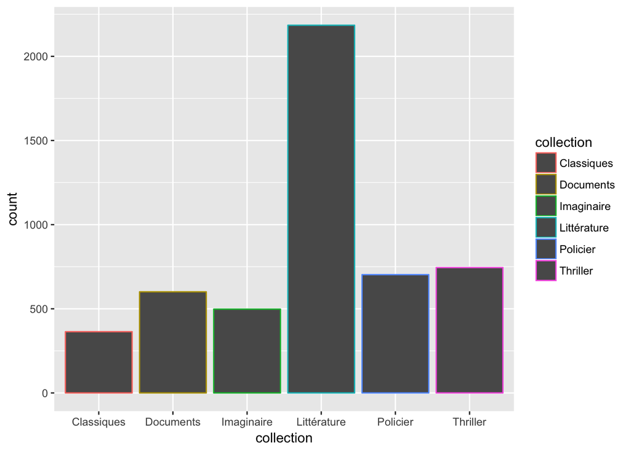

```r
library(ggplot2)
ggplot(data = dfBookSummaries) + geom_bar(mapping = aes(x = collection, colour = collection))
```

En effet cette collection représente plus de 40% du jeu de données :

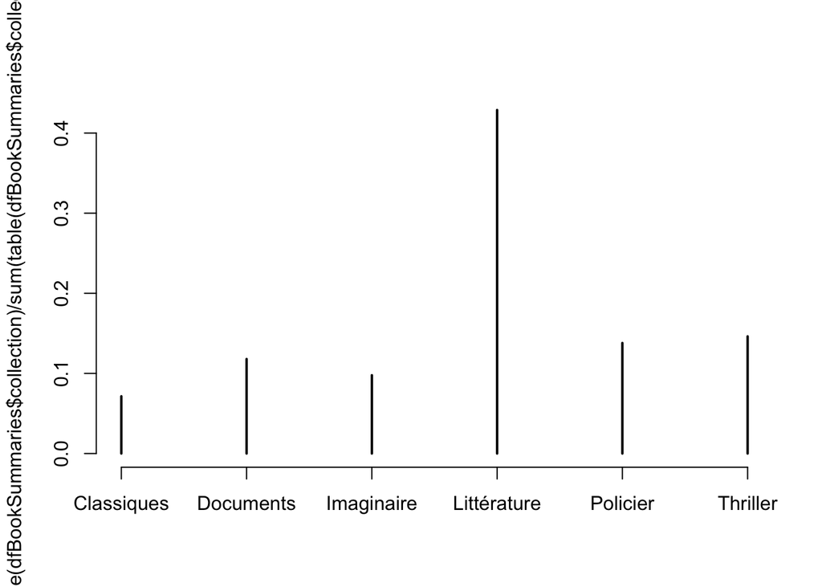

```r
plot(table(dfBookSummaries$collection) / sum(table(dfBookSummaries$collection)))
```

## Recherche de doublons

On s’intéresse maintenant à la présence éventuelle de doublons. En effet on ne peut pas préjuger de la qualité intrinsèque du catalogue de la maison d’édition. On va donc compter les doublons de résumés de livres :

```r
dfBookSummaries %>% count() - dfBookSummaries %>% select(text) %>% distinct() %>% count()
```

```
##    n
## 1 53
```

La requête a détecté 53 doublons. Apparaissent-ils entre plusieurs collections, auquel cas ces dernières ne sont peut-être pas pures ? Ou au contraire les doublons d’un même résumé restent-ils associés à la même collection ?

```r
dfBookSummaries %>% group_by(text) %>% summarise(nbDoublons = n(), nbCollections = n_distinct(collection)) %>% filter(nbDoublons > 1 | nbCollections > 1)
```

```
## # A tibble: 19 x 3
##    text                                           nbDoublons nbCollections
##    <chr>                                               <int>         <int>
##  1 "\n  \n        Résumé\n    \n  \n  \n    \n  …         36             6
##  2 "\n  \n        Résumé\n    \n  \n  \n    \n  …          2             1
##  3 "\n  \n        Résumé\n    \n  \n  \n    \n  …          2             1
##  4 "\n  \n        Résumé\n    \n  \n  \n    \n  …          2             1
##  5 "\n  \n        Résumé\n    \n  \n  \n    \n  …          2             1
##  6 "\n  \n        Résumé\n    \n  \n  \n    \n  …          2             1
##  7 "\n  \n        Résumé\n    \n  \n  \n    \n  …          2             1
##  8 "\n  \n        Résumé\n    \n  \n  \n    \n  …          2             1
##  9 "\n  \n        Résumé\n    \n  \n  \n    \n  …          2             1
## 10 "\n  \n        Résumé\n    \n  \n  \n    \n  …          2             1
## 11 "\n  \n        Résumé\n    \n  \n  \n    \n  …          2             1
## 12 "\n  \n        Résumé\n    \n  \n  \n    \n  …          2             1
## 13 "\n  \n        Résumé\n    \n  \n  \n    \n  …          2             1
## 14 "\n  \n        Résumé\n    \n  \n  \n    \n  …          2             1
## 15 "\n  \n        Résumé\n    \n  \n  \n    \n  …          2             1
## 16 "\n  \n        Résumé\n    \n  \n  \n    \n  …          2             1
## 17 "\n  \n        Résumé\n    \n  \n  \n    \n  …          2             1
## 18 "\n  \n        Résumé\n    \n  \n  \n    \n  …          2             1
## 19 "\n  \n        Résumé\n    \n  \n  \n    \n  …          2             1
```

Seuls les résumés “vides” sont dispersés sur les 6 collections. Les autres résumés représentent effectivement des doublons, mais restent dans leur collection. Les collections du Livre de Poche sont donc “pures”.

## Suppression des doublons et des résumés vides

On veut supprimer les doublons de résumés renseignés (on conservera donc le premier par exemple).

Pour supprimer tous les résumés vides, on opère un filter sur le dataframe.

```r
dfBookSummaries <- dfBookSummaries %>% distinct()

emptySummary <- dfBookSummaries %>% group_by(text) %>% summarise(nbDoublons = n(), nbCollections = n_distinct(collection)) %>% filter(nbDoublons > 1 | nbCollections > 1) %>% select(text)

keepOnlyLetters <- function (str) {
  result <- stri_replace_all_regex(str, "\\p{C}+", "")
  result <- stri_replace_all_regex(result, "\\p{Z}+", "")
  return(result)
}

dfBookSummaries <- dfBookSummaries %>% filter(keepOnlyLetters(text) != keepOnlyLetters(emptySummary))
```

On a donc supprimé 54 lignes du jeu de données (6 résumés vides et 48 doublons de résumés).

## Nettoyage du corpus de documents

Maintenant que nous avons supprimé les doublons et validé le jeu de données, nous pouvons normaliser le texte pour pouvoir ensuite l’analyser.

On se base sur le package tm, qui automatise une partie significative des traitements, et on le complète par le package stringi stringr qui gère très bien l’unicode et les regexps.

On créé d’abord le corpus :

```r
docs <- Corpus(VectorSource(dfBookSummaries$text))
dtm <- DocumentTermMatrix(docs)
dtm
```

```
## <<DocumentTermMatrix (documents: 5042, terms: 48614)>>
## Non-/sparse entries: 436444/244675344
## Sparsity           : 100%
## Maximal term length: 35
## Weighting          : term frequency (tf)
```

```r
inspect(docs[1])
```

```
## <<SimpleCorpus>>
## Metadata:  corpus specific: 1, document level (indexed): 0
## Content:  documents: 1
##
## [1] \n  \n        Résumé\n    \n  \n  \n    \n        \n  \n  \n      \n        \n      \n           Après avoir travaillé plusieurs années comme employé chez le parfumeur Ragon, César Birotteau reprend la direction de sa boutique. Ce commerçant doué invente des lotions qui font fureur et accroît…
```

Sans traitement notre DTM intègre 48614 termes (autant qu’un dictionnaire !). Sa sparsity (nombre de colonnes à 0) approche donc les 100% puisque nous disposons uniquement de 5042 documents.

Comme on peut le constater, le premier résumé contient un grand nombre de mots-outils (le la les). Le texte est aussi parsemé d’accents, de ponctuations, de caractères de fin de ligne, de majuscules, d’espaces…

On va donc retirer toutes ces exceptions pour que notre future matrice se compose de mots normalisés. On réduira ainsi la dimension et l’analyse en sera forcément plus pertinente.

On supprime d’abord les accents, car notre corpus est en français. Le texte étant encodé en UTF-8, nous allons exploiter une possibilité de l’Unicode pour supprimer les accents : la décomposition NFD. Celle-ci permet de transformer chaque caractère Unicode dans sa forme canonique, et de séparer les accents des lettres. Ensuite nous appliquons une regexp qui supprime spécifiquement les accents encodés UTF-8 de cette manière :

```r
nfdRemoveAccents <- function(x) {
  nfdX <- stri_trans_nfd(x)
  return(stri_replace_all_regex(nfdX, "\\p{Mn}+", ""))
}

docs <- tm_map(docs, content_transformer(nfdRemoveAccents))
inspect(docs[1])
```

```
## <<SimpleCorpus>>
## Metadata:  corpus specific: 1, document level (indexed): 0
## Content:  documents: 1
##
## [1] \n  \n        Resume\n    \n  \n  \n    \n        \n  \n  \n      \n        \n      \n           Apres avoir travaille plusieurs annees comme employe chez le parfumeur Ragon, Cesar Birotteau reprend la direction de sa boutique. Ce commercant doue invente des lotions qui font fureur et accroit…
```

Les accents ont tous disparu. On poursuit avec la normalisation de la casse via la fonction de tm :

```r
docs <- tm_map(docs, content_transformer(tolower))
inspect(docs[1])
```

```
## <<SimpleCorpus>>
## Metadata:  corpus specific: 1, document level (indexed): 0
## Content:  documents: 1
##
## [1] \n  \n        resume\n    \n  \n  \n    \n        \n  \n  \n      \n        \n      \n           apres avoir travaille plusieurs annees comme employe chez le parfumeur ragon, cesar birotteau reprend la direction de sa boutique. ce commercant doue invente des lotions qui font fureur et accroit…
```

On retire désormais la ponctuation et les caractères invisibles (dont les retours à la ligne, mais PAS encore les espaces). Pour ce faire, on recoure à plusieurs regexps sur les classes de caractères UTF-8 associées :

```r
removePonctuation <- function(x) {
  result <- x
  result <- stri_replace_all_regex(result, "\\p{Zl}+", " ")
  result <- stri_replace_all_regex(result, "\\p{Zp}+", " ")
  result <- stri_replace_all_regex(result, "\\p{S}+", " ")
  result <- stri_replace_all_regex(result, "\\p{N}+", " ")
  result <- stri_replace_all_regex(result, "\\p{C}+", " ")
  result <- stri_replace_all_regex(result, "\\p{P}+", " ")
  return(result)
}
docs <- tm_map(docs, content_transformer(removePonctuation))
inspect(docs[1])
```

```
## <<SimpleCorpus>>
## Metadata:  corpus specific: 1, document level (indexed): 0
## Content:  documents: 1
##
## [1]             resume                                                                  apres avoir travaille plusieurs annees comme employe chez le parfumeur ragon  cesar birotteau reprend la direction de sa boutique  ce commercant doue invente des lotions qui font fureur et accroit rapidement s…
```

Toutes les classes de caractère parasites sont désormais retirées, excepté les espaces. Pour les nombres, on aurait pu utiliser la fonction removeNumbers de tm, mais la regexp fonctionne aussi bien.

On s’attaque à présent à la suppression des stopwords, qui n’apportent aucune signification au texte et augmente la dimension inutilement. Le package tm propose une liste pour le français, que nous allons compléter par la suite.

```r
docs <- tm_map(docs, removeWords, stopwords("french"))
inspect(docs[1])
```

```
## <<SimpleCorpus>>
## Metadata:  corpus specific: 1, document level (indexed): 0
## Content:  documents: 1
##
## [1]             resume                                                                  apres avoir travaille plusieurs annees comme employe chez  parfumeur ragon  cesar birotteau reprend  direction   boutique   commercant doue invente  lotions  font fureur  accroit rapidement  fortune    voit pl…
```

```r
# docs <- tm_map(docs, removeWords, c("a", "plus", "les", "d", "l", "c", "d", "resume", "science-fiction", "ou", "plus", "tome", "serie", "roman", "romans", "collection", "livre", "gerard", "dirigee", "prix", "king", "auteur", "stephen", "alors", "aussi", "comme", "deux", "dont", "trois", "histoire", "jusqu", "encore", "etait", "etre", "meme", "recueil", "hugo", "quinze"))

# TODO : charger le fichier des stopwords de JL, et le nettoyer comme le corpus pour pour ensuite l'utiliser comme dictionnaire normalisé (minuscule, pas d'accents, pas de ponctuation)
# mySW = read.csv("jltStopwords.txt", sep = "", stringsAsFactors = FALSE, header = FALSE)
# docs <- tm_map(docs, removeWords, mySW$V1)
```

TODO : On veut pouvoir s’assurer que la grande majorité des stopwords a été supprimée. On va donc extraire les mots les plus fréquents dans le corpus et retirer ceux qui sont des mots-outils :

```r
# TODO : en cours
dtm <- DocumentTermMatrix(docs)
minfreq <- findFreqTerms(dtm, 80,100)
```

TODO : Essai sur la racinisation du texte, …

```r
# docs <- nonStemmedDocs
# nonStemmedDocs <- docs
# docs <- tm_map(docs, stemDocument, "french")
# docs[1]$content
# stemCompletion('resum',dictionary=nonStemmedDocs)  #remarque le stemming fait perdre la lisibilite, on peut la retrouver avec stemCompletion
#
# dtm <- DocumentTermMatrix(docs)
# dtm
# TODO : voir s'il faut éliminer les mots de moins de 2/3 lettres
```

```r
docs <- tm_map(docs, stripWhitespace)
inspect(docs[1])
```

```
## <<SimpleCorpus>>
## Metadata:  corpus specific: 1, document level (indexed): 0
## Content:  documents: 1
##
## [1]  resume apres avoir travaille plusieurs annees comme employe chez parfumeur ragon cesar birotteau reprend direction boutique commercant doue invente lotions font fureur accroit rapidement fortune voit plus loin reve integrer plus haute societe alors quand propose acheter terrains a batir vers…
```

```r
dtm <- DocumentTermMatrix(docs)
dtm
```

```
## <<DocumentTermMatrix (documents: 5042, terms: 39584)>>
## Non-/sparse entries: 358689/199223839
## Sparsity           : 100%
## Maximal term length: 30
## Weighting          : term frequency (tf)
```

## Statistiques descriptives

On souhaite désormais décrire un peu mieux notre DTM. Pour ce faire, en génère une nouvelle avec une pondération TF qui va nous permettre de calculer la distribution du nombre de mots dans les résumés, par collection, …

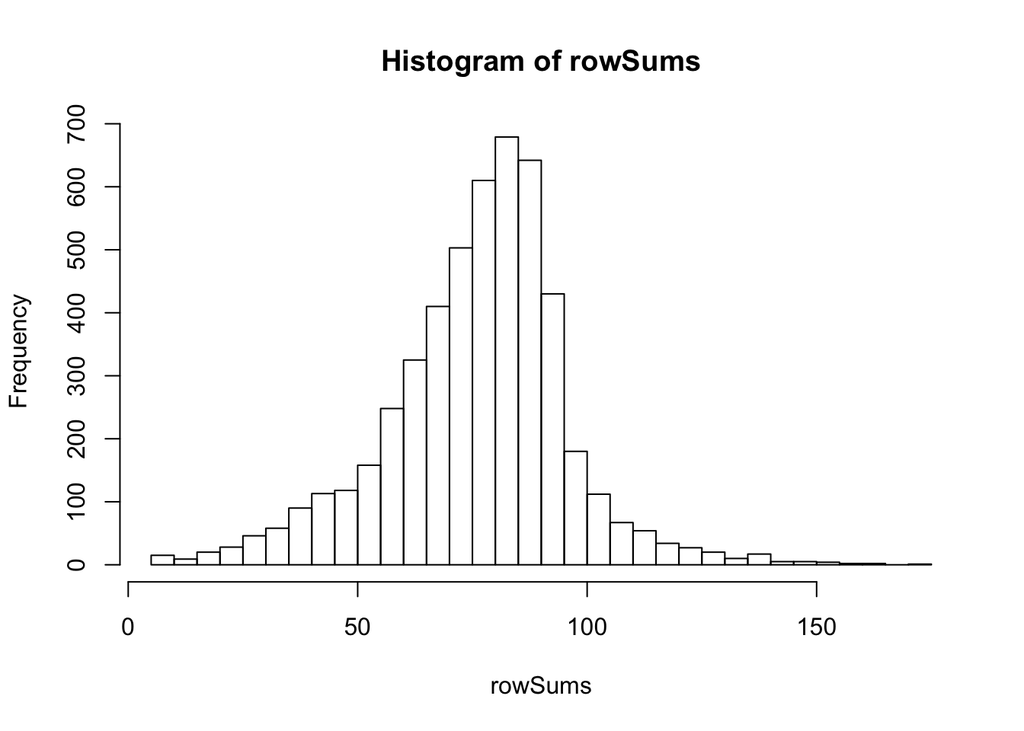

```r
dtmTf <- DocumentTermMatrix(docs, control=list(weighting=weightTf))
dtmTf_m <- as.matrix(dtmTf)
rowSums <- rowSums(dtmTf_m)
dtmTf <- NULL
dtmTf_m <- NULL
hist(rowSums,breaks=25)
```

Intéressons nous ensuite à la distribution du nombre de mots par collection :

```r
summary(rowSums)
```

```
##    Min. 1st Qu.  Median    Mean 3rd Qu.    Max.
##    5.00   66.00   79.00   76.47   88.00  175.00
```

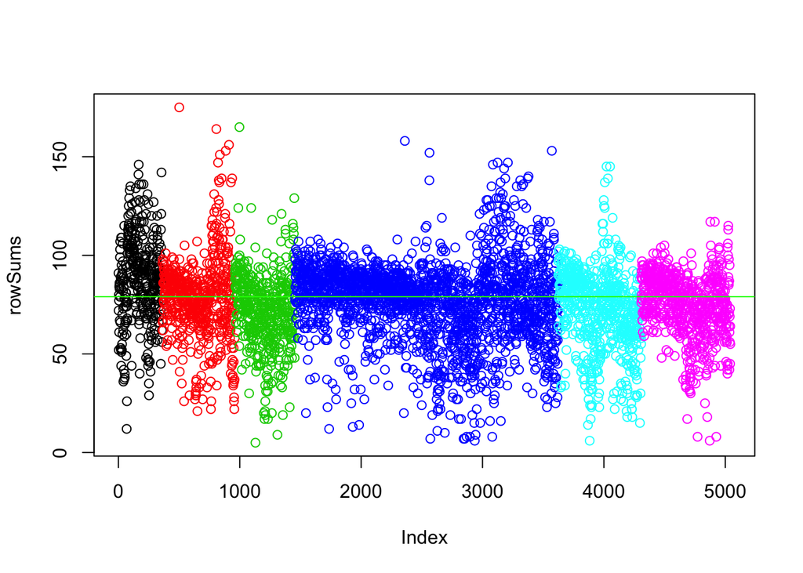

```r
plot(rowSums, col = dfBookSummaries$collection)
abline(h=median(rowSums), col = "green")
```

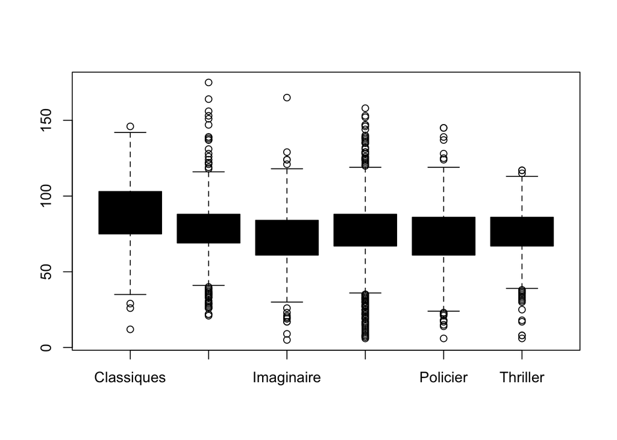

```r
boxplot(rowSums~dfBookSummaries$collection, col = dfBookSummaries$collection)
```

## Réduction de la dimension

Bien que nous ayons normalisé le texte, retiré les stopwords et tous les caractères parasites, notre matrice possède encore presque 40k colonnes !

On va réduire le vocabulaire : au lieu de prendre les mots apparaissant au moins une fois, on prend le nombre de mots apparaissant au moins 5 fois afin de limiter un peu le nombre de colonnes avant meme de calculer la matrice. Ce nombre est choisi arbitrairement : le vocabulaire du corpus représentant 40k mots sur 5k articles, 5 semble légitimement faible.

TODO : On pourrait aussi réduire la dimension avec la fonction removeSparseTerms de tm.

```r
minfreq <- findFreqTerms(dtm, 5)
dtm <- DocumentTermMatrix(docs, control=list(dictionary = minfreq, weighting=weightTfIdf))
dtm
```

```
## <<DocumentTermMatrix (documents: 5042, terms: 11002)>>
## Non-/sparse entries: 308157/55163927
## Sparsity           : 99%
## Maximal term length: 18
## Weighting          : term frequency - inverse document frequency (normalized) (tf-idf)
```

```r
dtm_m <- as.matrix(dtm) # renvoie pour chaque document le nombre d'occurrences de chaque terme y figurant
```

La sparsity étant encore très elevée, on retire les mots les plus rares pour réduire un peu la dimension, ie. ceux qui apparaissent dans moins d’1% des documents. Cela semble beaucoup plus efficace qu’en conservant les mots assez fréquents.

```r
dtm <- DocumentTermMatrix(docs, control=list(weighting=weightTfIdf))
dtm <- removeSparseTerms(dtm, 0.99)
dtm
```

```
## <<DocumentTermMatrix (documents: 5042, terms: 1184)>>
## Non-/sparse entries: 178464/5791264
## Sparsity           : 97%
## Maximal term length: 16
## Weighting          : term frequency - inverse document frequency (normalized) (tf-idf)
```

```r
dtm_m <- as.matrix(dtm) # renvoie pour chaque document le nombre d'occurrences de chaque terme y figurant
```

TODO : On tente ensuite une ACP sur la matrice (trop long, code commenté)

Voir : https://www.usna.edu/Users/cs/lmcdowel/pubs/UnderhillIRI2007Final.pdf Et : https://www.kdnuggets.com/2015/05/7-methods-data-dimensionality-reduction.html

```r
# install.packages("FactoMineR")
# library(FactoMineR)
# PCAResult <- PCA(dtm_m, scale.unit = FALSE, ncp = 10)
```

## Nuages de mots

A présent que nous disposons d’une matrice relativement propre, nous allons générer un nuage de mots par collection pour tenter de faire émerger quelques thèmes :

```r
collections <- levels(dfBookSummaries$collection)

for (i in 1:length(collections)) {
  m <- dtm_m[dfBookSummaries$collection == collections[i],]
  wordsFreq <- sort(colSums(m),decreasing = TRUE)
  wordsFreq <- data.frame(word = names(wordsFreq), Freq = as.vector(wordsFreq)) # mise au format pour wordcloud2
  print(wordcloud2(data = wordsFreq[1:500,],minSize = 1, size = 3))
  }
```

[output not shown]

## TODO : Classification non supervisée LDA (Topic Modeling) / SKmeans / CAH / ACP / …

### SKmeans

```r
# install.packages("skmeans")
library(skmeans)
tdm <-TermDocumentMatrix(docs)
dim(tdm)
```

```
## [1] 39584  5042
```

```r
tdmss <- removeSparseTerms(tdm, 0.99)
dim(tdmss)
```

```
## [1] 1185 5042
```

```r
sk <- skmeans(x=tdmss, 6) # on a choisi de voir ce qui ressortait pour 6 classes (pour voir si on retrouve les 6 collections utilisées pour classer les articles)

## proportion par classe:
table(sk$cluster)/sum(table(sk$cluster))
```

```
##
##         1         2         3         4         5         6
## 0.2860759 0.1586498 0.1367089 0.1291139 0.1679325 0.1215190
```

```r
for (i in 1:6){
  print(paste('cluster ',i,sep=' '))
  print(names(sk$cluster)[sk$cluster==i][1:50])
  print('---------------')
}
```

```
## [1] "cluster  1"
##  [1] "alors"     "apres"     "avoir"     "chez"      "comme"
##  [6] "debut"     "fait"      "famille"   "font"      "humaine"
## [11] "loin"      "plus"      "quand"     "resume"    "reve"
## [16] "vers"      "vie"       "amour"     "deux"      "dieu"
## [21] "donne"     "fois"      "plaisir"   "signe"     "sous"
## [26] "tendresse" "toujours"  "voix"      "chacun"    "dont"
## [31] "jour"      "quatre"    "tous"      "tout"      "vingt"
## [36] "ans"       "avant"     "contre"    "etre"      "jeune"
## [41] "jours"     "lorsqu"    "oublier"   "peut"      "pose"
## [46] "puis"      "quinze"    "surtout"   "tard"      "venir"
## [1] "---------------"
## [1] "cluster  2"
##  [1] "aussi"       "ecrit"       "edition"     "haute"       "moderne"
##  [6] "offre"       "plusieurs"   "propose"     "siecle"      "societe"
```

[output cut: 63 more lines]

```r
## On partitionne en 6 clusters.
dtm <-DocumentTermMatrix(docs)
dim(dtm)
```

```
## [1]  5042 39584
```

```r
dtmss <- removeSparseTerms(dtm, 0.99)
dim(dtmss)
```

```
## [1] 5042 1185
```

```r
sk <- skmeans(x=dtmss, 6)
## On regarde la r?partition dans les clusters
table(sk$cluster)/sum(table(sk$cluster))
```

```
##
##         1         2         3         4         5         6
## 0.1537088 0.1378421 0.1332804 0.2114240 0.1382388 0.2255058
```

```r
dtmss_m <- as.matrix(dtmss)
for (i in 1:6){
  m <- dtmss_m[sk$cluster==i,]
  wordsFreq <- sort(colSums(m),decreasing = TRUE)
  wordsFreq <- data.frame(word = names(wordsFreq), Freq = as.vector(wordsFreq)) # mise au format pour wordcloud2
  print(wordcloud2(data = wordsFreq[1:500,],minSize = 1, size = 3))}
```

[output not shown]

La LDA s’applique sur une matrice documents termes sans pond?ration (nombre d’occurrences).

```r
# TODO : topic modeling pour adresser les synonymes ?
# Similarité entre mots
# TODO : findAssocs(dtm, terms = "monde", corlimit = 0.3)
# TODO : Word2Vec : mais pour faire quoi exactement dans notre cas ?
# TODO : Classification non supervisée : SKmeans / CAH / LDA
# TODO : tester la précision des catégories vs. les Y de sortie du premier dataframe (for JL : "accuracy").
# TODO : kmeans et CAH (sur matrice nettoyée)
```